# Park_Lab4

Patricia Park

2024-02-08

## Lab 4: Fire and Tree Mortality

The database we’ll be working with today includes 36066 observations of individual trees involved in prescribed fires and wildfires occurring over 35 years, from 1981 to 2016. It is a subset of a larger fire and tree mortality database from the US Forest Service (see data description for the full database here: [link](https://www.nature.com/articles/s41597-020-0522-7#Sec10)). Our goal today is to predict the likelihood of tree mortality after a fire.

### Data Exploration

Outcome variable: *yr1status* = tree status (0=alive, 1=dead) assessed one year post-fire.

Predictors: *YrFireName, Species, Genus_species, DBH_cm, CVS_percent, BCHM_m, BTL* (Information on these variables available in the database metadata ([link](https://www.fs.usda.gov/rds/archive/products/RDS-2020-0001-2/_metadata_RDS-2020-0001-2.html))).

```r
trees_dat<- read_csv(file = "https://raw.githubusercontent.com/MaRo406/eds-232-machine-learning/main/data/trees-dat.csv")
```

> Question 1: Recode all the predictors to a zero_based integer form

```r
#specify and prep recipe
trees_rec <- recipe(yr1status ~., data = trees_dat) %>%
  step_integer(all_predictors(), zero_based = T) %>%
  prep(trees_dat) %>%
  bake(trees_dat)
```

### Data Splitting

> Question 2: Create trees_training (70%) and trees_test (30%) splits for the modeling

```r
set.seed(123)  # for reproducibility
trees_split <- initial_split(trees_rec, prop = .7)
trees_train <- training(trees_split)
trees_test  <- testing(trees_split)
```

> Question 3: How many observations are we using for training with this split?

```r
#find how many observations we have
tree_train_ob <- nrow(trees_train)
print(tree_train_ob)
```

```
## [1] 25246
```

**Answer**: We have 25246 observations that we are using for the training data.

### Simple Logistic Regression

Let’s start our modeling effort with some simple models: one predictor and one outcome each.

> Question 4: Choose the three predictors that most highly correlate with our outcome variable for further investigation.

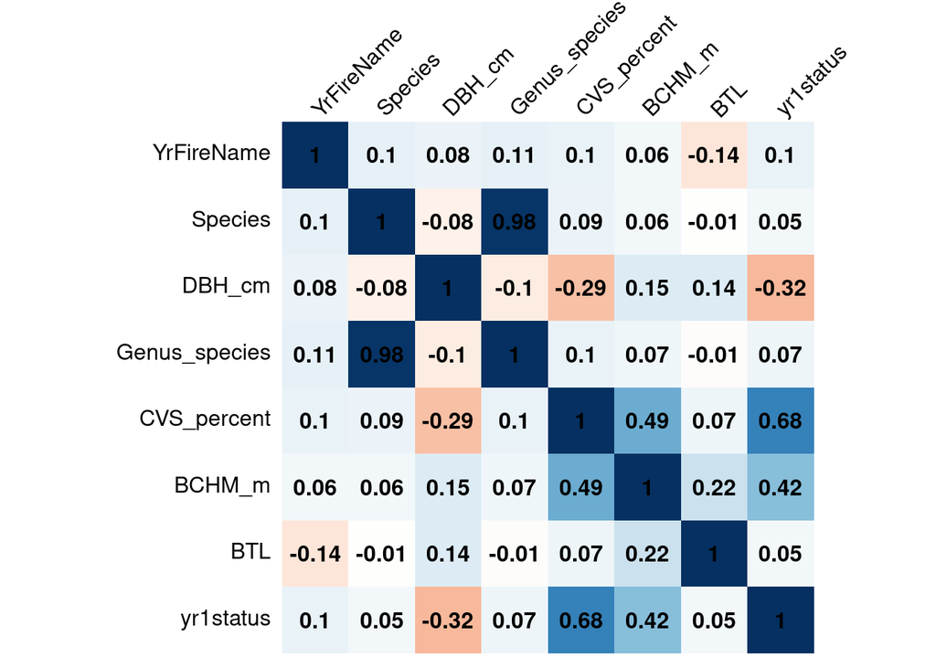

```r
# Obtain correlation matrix
corr_mat <- cor(trees_rec %>%
                  # Drop columns that are not really informative
                  select(-c(`...1`)))

# Make a correlation plot between the variables
corrplot(corr_mat, method = "shade", shade.col = NA, tl.col = "black", tl.srt = 45, addCoef.col = "black", cl.pos = "n", order = "original")
```

**Answer**: The three predictors that most highly correlate with our outcome variables `yr1status` are `CVS_percent`, `BCHM_m`, and `DBH_cm`.

> Question 5: Use glm() to fit three simple logistic regression models, one for each of the predictors you identified.

```r
#CVS_percent
model_CVS <- glm(data = trees_rec, yr1status ~ CVS_percent, family = "binomial")

#BCHM_m
model_BCHM <- glm(data = trees_rec, yr1status ~ BCHM_m, family = "binomial")

#DBH_cm
model_DBH <- glm(data = trees_rec, yr1status ~ DBH_cm, family = "binomial")
```

### Interpret the Coefficients

We aren’t always interested in or able to interpret the model coefficients in a machine learning task. Often predictive accuracy is all we care about.

> Question 6: That said, take a stab at interpreting our model coefficients now.

```r
#show the model coefficients
broom::tidy(model_CVS)
```

```
## # A tibble: 2 × 5
##   term        estimate std.error statistic p.value
##   <chr>          <dbl>     <dbl>     <dbl>   <dbl>
## 1 (Intercept)  -6.72     0.0952      -70.6       0
## 2 CVS_percent   0.0774   0.00104      74.5       0
```

```r
broom::tidy(model_BCHM)
```

```
## # A tibble: 2 × 5
##   term        estimate std.error statistic p.value
##   <chr>          <dbl>     <dbl>     <dbl>   <dbl>
## 1 (Intercept) -1.99    0.0202        -98.4       0
## 2 BCHM_m       0.00625 0.0000872      71.7       0
```

```r
broom::tidy(model_DBH)
```

```
## # A tibble: 2 × 5
##   term        estimate std.error statistic  p.value
##   <chr>          <dbl>     <dbl>     <dbl>    <dbl>
## 1 (Intercept)  0.382   0.0236         16.2 7.59e-59
## 2 DBH_cm      -0.00370 0.0000645     -57.3 0
```

```r
# (coef(model_CVS))
# (coef(model_BCHM))
# (coef(model_DBH))
```

> Question 7: Now let’s visualize the results from these models. Plot the fit to the training data of each model.

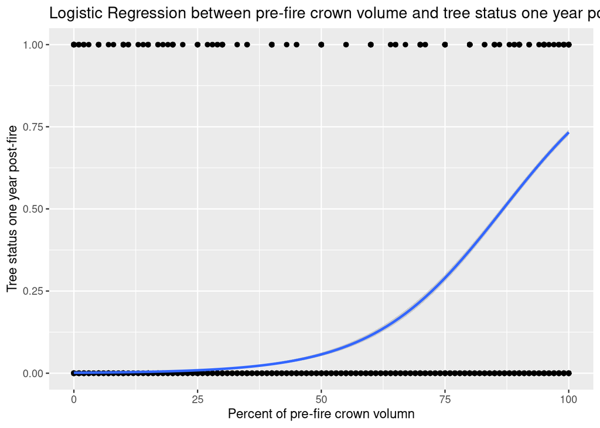

```r
#logistic regression plot for CVS_percent
ggplot(trees_train, aes(x = CVS_percent, y = yr1status)) + geom_point() +
  stat_smooth(method = "glm", se = T, method.args = list(family = binomial)) +
  labs(title = "Logistic Regression between pre-fire crown volume and tree status one year post-fire",
       x = "Percent of pre-fire crown volumn",
       y = "Tree status one year post-fire")
```

[figure not shown]

```r
#logistic regression plot for BCHM_m
ggplot(trees_train, aes(x = BCHM_m, y = yr1status)) + geom_point() +
  stat_smooth(method = "glm", se = T, method.args = list(family = binomial)) +
  labs(title = "Logistic Regression between Trunk Diameter and tree status one year post-fire",
       x = "Trunk Diameter (cm)",
       y = "Tree status one year post-fire")
```

[figure not shown]

```r
#logistic regression plot for DBH_cm
ggplot(trees_train, aes(x = DBH_cm, y = yr1status)) + geom_point() +
  stat_smooth(method = "glm", se = T, method.args = list(family = binomial)) +
  labs(title = "Logistic Regression between Maximum bark char and tree status one year post-fire",
       x = "Maximum bark char (m)",
       y = "Tree status one year post-fire")
```

*Note*: It’s interesting to see that for the lm line for the BCHM_m, it follows a near perfect logistic line. The regression line for CVS_percent leans more towards zero as well as the DBH_cm graph.

### Multiple Logistic Regression (chapter 5)

Let’s not limit ourselves to a single-predictor model. More predictors might lead to better model performance.

> Question 8: Use glm() to fit a multiple logistic regression called “logistic_full”, with all three of the predictors included. Which of these are significant in the resulting model?

```r
#multiple logistic regression on all variables we are interested in
logistic_full <- glm(data = trees_rec, yr1status ~ DBH_cm + CVS_percent + BCHM_m, family = "binomial")
broom::tidy(logistic_full)
```

```
## # A tibble: 4 × 5
##   term        estimate std.error statistic   p.value
##   <chr>          <dbl>     <dbl>     <dbl>     <dbl>
## 1 (Intercept) -5.21    0.0973        -53.6 0
## 2 DBH_cm      -0.00358 0.0000982     -36.5 3.47e-291
## 3 CVS_percent  0.0632  0.00101        62.3 0
## 4 BCHM_m       0.00462 0.000134       34.4 5.65e-259
```

**Answer**: While all of these predictors are significant in the resulting model, CVS_percent is more significant than the other predictors as the p_value is a near 0 as seen on the table. The estimate coefficient is also very high compared to the other predictors coefficients.

### Estimate Model Accuracy

Now we want to estimate our model’s generalizability using resampling.

> Question 9: Use cross validation to assess model accuracy. Use caret::train() to fit four 10-fold cross-validated models (cv_model1, cv_model2, cv_model3, cv_model4) that correspond to each of the four models we’ve fit so far: three simple logistic regression models corresponding to each of the three key predictors (CVS_percent, DBH_cm, BCHM_m) and a multiple logistic regression model that combines all three predictors.

```r
#change the outcomes to factors
trees_train$yr1status <- as.factor(trees_train$yr1status)

#create the cross-validation modes for all predictors
#DBH_cm
cv_model1 <- train(yr1status~DBH_cm,
                   data = trees_train,
                   method = 'glm',
                   family = 'binomial',
                   trControl = trainControl(method = 'cv', number = 10))

#CVS_percent
cv_model2 <- train(yr1status~ CVS_percent,
                   data = trees_train,
                   method = 'glm',
                   family = 'binomial',
                   trControl = trainControl(method = 'cv', number = 10))

#BCHM_m
cv_model3 <- train(yr1status ~BCHM_m,
                   data = trees_train,
                   method = 'glm',
                   family = 'binomial',
                   trControl = trainControl(method = 'cv', number = 10))

#DBH_cm, CVS_percent, and BCHM_m
cv_model4 <- train(yr1status ~DBH_cm + CVS_percent + BCHM_m,
                   data = trees_train,
                   method = 'glm',
                   family = 'binomial',
                   trControl = trainControl(method = 'cv', number = 10))
```

> Question 10: Use caret::resamples() to extract then compare the classification accuracy for each model. (Hint: resamples() wont give you what you need unless you convert the outcome variable to factor form). Which model has the highest accuracy?

```r
#print the summary of all models to see r squared, RSME
summary(caret::resamples(list(model1 = cv_model1,
                       model2 = cv_model2,
                       model3 = cv_model3,
                       model4 = cv_model4)))
```

```
##
## Call:
## summary.resamples(object = caret::resamples(list(model1 = cv_model1, model2
##  = cv_model2, model3 = cv_model3, model4 = cv_model4)))
##
## Models: model1, model2, model3, model4
## Number of resamples: 10
##
## Accuracy
##             Min.   1st Qu.    Median      Mean   3rd Qu.      Max. NA's
## model1 0.7476228 0.7488363 0.7506931 0.7525153 0.7535399 0.7619802    0
## model2 0.8902970 0.8924431 0.8980198 0.8975283 0.9014560 0.9064976    0
## model3 0.7588119 0.7690099 0.7728713 0.7715290 0.7763471 0.7777338    0
## model4 0.8887129 0.8998711 0.9047147 0.9029551 0.9069215 0.9093069    0
##
## Kappa
##             Min.   1st Qu.    Median      Mean   3rd Qu.      Max. NA's
## model1 0.2087847 0.2214217 0.2275294 0.2288585 0.2377112 0.2568056    0
## model2 0.7476037 0.7528272 0.7652342 0.7638402 0.7722342 0.7815808    0
## model3 0.3050506 0.3316966 0.3427780 0.3383590 0.3523634 0.3582935    0
## model4 0.7377438 0.7620979 0.7709635 0.7683553 0.7773960 0.7841788    0
```

**Answer**: The best model is model four. There are two models that do look good, which is model 2, using the `CVS_percent` being regressed on and model 4, using all three variables that are being regressed on. I picked model four to be the best model as on average, the accuracy was higher for model 4.

Let’s move forward with this single most accurate model.

> Question 11: Compute the confusion matrix and overall fraction of correct predictions by the model.

```r
#create predict for cv_model4 on training data
pred_class <- predict(cv_model4, trees_train)
# making confusion matrix
confusionMatrix(
  data = relevel(pred_class, ref = '1'),
  reference = relevel(trees_train$yr1status, ref = "1"))
```

```
## Confusion Matrix and Statistics
##
##           Reference
## Prediction     1     0
##          1  6300  1595
##          0   847 16504
##
##                Accuracy : 0.9033
##                  95% CI : (0.8996, 0.9069)
##     No Information Rate : 0.7169
##     P-Value [Acc > NIR] : < 2.2e-16
##
##                   Kappa : 0.769
##
##  Mcnemar's Test P-Value : < 2.2e-16
##
##             Sensitivity : 0.8815
##             Specificity : 0.9119
##          Pos Pred Value : 0.7980
##          Neg Pred Value : 0.9512
##              Prevalence : 0.2831
##          Detection Rate : 0.2495
##    Detection Prevalence : 0.3127
##       Balanced Accuracy : 0.8967
##
##        'Positive' Class : 1
##
```

> Question 13: What is the overall accuracy of the model? How is this calculated?

**Answer**: The overall accuracy of the training model is around 90% or 0.9033. This is calculated by dividing the total number of correct samples by the total number of samples. We can also test how well the total accuracy is in the model by looking at the no information rate. If our accuracy rate is above the no information rate, our model is more likely to have a better ROC curve. In this case, our no information rate is about 72% or 0.7169. Since our overall accuracy is well above our overall accuracy, we can trust that we have a good model.

### Test Final Model

Alright, now we’ll take our most accurate model and make predictions on some unseen data (the test data).

> Question 14: Now that we have identified our best model, evaluate it by running a prediction on the test data, trees_test.

```r
#create predict for cv_model4 on testing data
test_predict <- predict(cv_model4, trees_test)

#make confusion matrix
confusionMatrix(
  data = relevel(test_predict, ref = '1'),
  reference = relevel(as.factor(trees_test$yr1status), ref = "1"))
```

```
## Confusion Matrix and Statistics
##
##           Reference
## Prediction    1    0
##          1 2724  721
##          0  362 7013
##
##                Accuracy : 0.8999
##                  95% CI : (0.8941, 0.9055)
##     No Information Rate : 0.7148
##     P-Value [Acc > NIR] : < 2.2e-16
##
##                   Kappa : 0.7628
##
##  Mcnemar's Test P-Value : < 2.2e-16
##
##             Sensitivity : 0.8827
##             Specificity : 0.9068
##          Pos Pred Value : 0.7907
##          Neg Pred Value : 0.9509
##              Prevalence : 0.2852
##          Detection Rate : 0.2518
##    Detection Prevalence : 0.3184
##       Balanced Accuracy : 0.8947
##
##        'Positive' Class : 1
##
```

> Question 15: How does the accuracy of this final model on the test data compare to its cross validation accuracy? Do you find this to be surprising? Why or why not?

**Answer**: Looking at the confusion matrix, the overall accuracy of this model is about 90% or 0.8999. I find this surprising because this is saying that the model is very accurate in its prediction. This accuracy for the final model is almost the same as the model used for the training data. Looking also at the sensitivity and specificity rate, I am surprised of the high rate. I would have assumed that it would have gone down, but with it being in the high 80’s, I can have more confidence that the this is a strong model. Another thing that I was surprised was the no information rate being well below our accuracy rate. In testing the final model, I get a no information rate of around 71 % or 0.7148. Because this is well below our overall accuracy percent, this tells me that our model is strong, meaning if we plot our ROC curve, we would get a high AUC which we want.